# 1 KNN_self

- 文件说明
  - KNN_sk.py -- > 使用sklearn库实现KNN算法
  - KNN_self.py -- > 使用KNN算法实现MNIST数据集预测
  - show_img.py --> 显示图片
  - gauss.csv --> 高斯数据集
- 文件依赖关系 \

[figure not shown]

## 1.1 查看图片

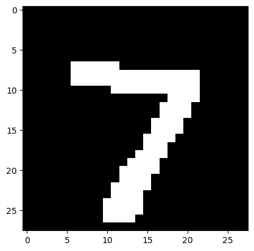

```python
import matplotlib.pyplot as plt
import numpy as np
import pylab
import os

m_x = np.loadtxt('mnist_x.txt', delimiter=' ')
m_y = np.loadtxt('mnist_y.txt')

data = np.reshape(np.array(m_x[0], dtype=int), [28, 28])
plt.figure()
plt.imshow(data, cmap='gray')
pylab.show()
```

## 数据集介绍

- mnist_x.txt

$$ X =\begin{bmatrix} x_{0,0} & x_{0,1} & \cdots & x_{0,783} \\ x_{1,0} & x_{1,1} & \cdots & x_{1,783} \\ x_{2,0} & x_{2,1} & \cdots & x_{2,783} \\ \cdots & \cdots & \cdots & \cdots \\ x_{999,0} & x_{999,1} & \cdots & x_{999,783} \end{bmatrix} $$

- mnist_y.txt

$$ Y=\begin{bmatrix} y_{0} \\ y_{1} \\ y_{2} \\ \cdots \\ y_{999} \end{bmatrix} $$

Y中每一行代表一张图片的标签，共1000张图片，因此Y是一个1000*1的矩阵。

- 训练集以及测试集划分

$$ X_{train} : X_{test} = 0.8 : 0.2 \\ Y_{train} : Y_{test} = 0.8 : 0.2 \\ $$

## 算法思想

- KNN算法是一种基于实例的学习，即它没有显式的训练过程，而是直接使用训练数据来预测测试数据。KNN算法的核心思想是：如果一个样本在特征空间中的K个最相似（即特征空间中最邻近）的样本中的大多数属于某一个类别，则该样本也属于这个类别。KNN算法的步骤如下：
1. 计算待分类样本与所有已知样本的距离。
2. 找出距离最近的K个已知样本。
3. 统计这K个已知样本中各个类别的数量。
4. 将待分类样本归为数量最多的类别。

## 3. KNN算法实现

[figure not shown]

```python
ratio = 0.8
split = int(len(m_x) * ratio)
np.random.seed(0)
idx = np.random.permutation(np.arange(len(m_x)))
m_x = m_x[idx]
m_y = m_y[idx]
x_train, x_test = m_x[:split], m_x[split:]
y_train, y_test = m_y[:split], m_y[split:]
def distance(a, b):
    return np.sqrt(np.sum(np.square(a - b)))
class KNN:
    def __init__(self, k, label_num):
        self.k = k
        self.label_num = label_num

    def fit(self, x_train, y_train):
        self.x_train = x_train
        self.y_train = y_train

    def get_knn_indices(self, x):
        dis = list(map(lambda a: distance(a, x), self.x_train))
        knn_indices = np.argsort(dis)
        knn_indices = knn_indices[:self.k]
        return knn_indices

    def get_label(self, x):
        knn_indices = self.get_knn_indices(x)
        label_statistic = np.zeros(shape=[self.label_num])
        for index in knn_indices:
            label = int(self.y_train[index])
            label_statistic[label] += 1
        return np.argmax(label_statistic)

    def predict(self, x_test):
        predicted_test_labels = np.zeros(shape=[len(x_test)], dtype=int)
        for i, x in enumerate(x_test):
            predicted_test_labels[i] = self.get_label(x)
        return predicted_test_labels
for k in range(1, 10):
    knn = KNN(k, label_num=10)
    knn.fit(x_train, y_train)
    predicted_labels = knn.predict(x_test)

    accuracy = np.mean(predicted_labels == y_test)
    print(f'K的取值为 {k}, 预测准确率为 {accuracy * 100:.1f}%')
```

```
K的取值为 1, 预测准确率为 88.5%
K的取值为 2, 预测准确率为 88.0%
K的取值为 3, 预测准确率为 87.5%
K的取值为 4, 预测准确率为 87.5%
K的取值为 5, 预测准确率为 88.5%
K的取值为 6, 预测准确率为 88.5%
K的取值为 7, 预测准确率为 88.0%
K的取值为 8, 预测准确率为 87.0%
K的取值为 9, 预测准确率为 87.0%
```

# KNN_sk

## 数据集介绍

```python
from sklearn.neighbors import KNeighborsClassifier
from matplotlib.colors import ListedColormap
import matplotlib.pyplot as plt
import numpy as np
import os
from tqdm import tqdm

data = np.loadtxt('gauss.csv', delimiter=',')
x_train = data[:, :2]
y_train = data[:, 2]
print('数据集大小：', len(x_train))
```

```
数据集大小： 200
```

```python
import pandas as pd
x_lable0 = pd.DataFrame(x_train[y_train == 0, 0])
y_lable0 = pd.DataFrame(x_train[y_train == 0, 1])
x_lable1 = pd.DataFrame(x_train[y_train == 1, 0])
y_lable1 = pd.DataFrame(x_train[y_train == 1, 1])
```

```python
x_lable0.describe()
```

|  | 0 |
| --- | --- |
| count | 100.000000 |
| mean | 1.027601 |
| std | 0.788358 |
| min | -0.828000 |
| 25% | 0.538450 |
| 50% | 1.018950 |
| 75% | 1.509500 |
| max | 3.106800 |

```python
test = pd.DataFrame({
    "x0":x_lable0.describe().T.to_numpy()[0],
    "x1":x_lable1.describe().T.to_numpy()[0],
    "y0":y_lable0.describe().T.to_numpy()[0],
    "y1":y_lable1.describe().T.to_numpy()[0]
              },index=['1','均值','方差'] + (list(range(5))))
test.iloc[[1,2],:]
```

[output not shown]

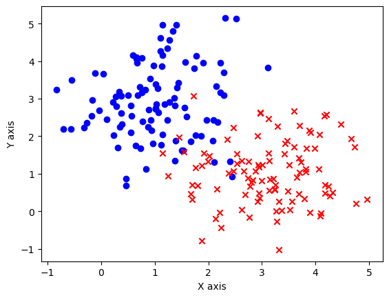

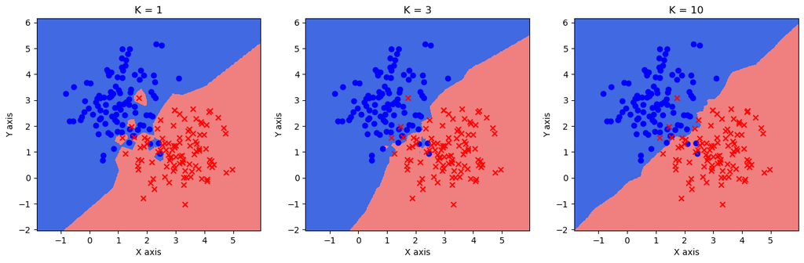

```python
plt.figure()
plt.scatter(x_train[y_train == 0, 0], x_train[y_train == 0, 1], c='blue', marker='o')
plt.scatter(x_train[y_train == 1, 0], x_train[y_train == 1, 1], c='red', marker='x')
plt.xlabel('X axis')
plt.ylabel('Y axis')
plt.show()

step = 0.02
x_min, x_max = np.min(x_train[:, 0]) - 1, np.max(x_train[:, 0]) + 1
y_min, y_max = np.min(x_train[:, 1]) - 1, np.max(x_train[:, 1]) + 1
xx, yy = np.meshgrid(np.arange(x_min, x_max, step), np.arange(y_min, y_max, step))
grid_data = np.concatenate([xx.reshape(-1, 1), yy.reshape(-1, 1)], axis=1)

fig = plt.figure(figsize=(16,4.5))


ks = [1,3,10]
cmap_light = ListedColormap(['royalblue','lightcoral'])

for i, k in enumerate(tqdm(ks)):
    knn = KNeighborsClassifier(n_neighbors=k)
    knn.fit(x_train, y_train)
    y_pred = knn.predict(grid_data)
    ax = fig.add_subplot(1, 3, i+1)
    ax.pcolormesh(xx, yy, y_pred.reshape(xx.shape), cmap=cmap_light)
    ax.scatter(x_train[y_train == 0, 0], x_train[y_train == 0, 1], c='blue', marker='o')
    ax.scatter(x_train[y_train == 1, 0], x_train[y_train == 1, 1], c='red', marker='x')
    ax.set_xlabel('X axis')
    ax.set_ylabel('Y axis')
    ax.set_title(f'K = {k}')
plt.show()
```